# Reseach Questions

Ulita Gilbert

4/14/2021

# 1 Introduction

In this part of my project I will refine my research questions. I will further examine the effects of the pandemic on recent MCPS highschool graduates enrolled at Montgomery College. For the purposes of this study I will limit my dataset to MCPS students under the age of 20. These MCPS students will be divided further into subgroups based on Gender and Race. The datasets used in this part of my project have already been cleaned in my initial data analysis. Outliers have not been removed. I will conduct my statistical analysis with and without the outliers.

# 2 Data Dictionary

For the purposes of this Project the following variables and definitions are important.

The population in this dataset is the incoming cohort of students in Fall of 2019 and 2020. These students are first time degree or certificate seekers and have no prior tertiary education. They may have earned AP credits in highschool.

**Fall2019** refers to the incoming freshman cohort in Fall2019. This is term year 2020.  
**Fall2020** refers to the incoming freshman cohort in Fall2020. This is term year 2021.

**Variables of Interest:** **term year** Incoming students in Fall2019 are assigned to term year 2020. Incoming students in Fall 2020 are assigned to term year 2021.  
**hours_earned:** refers to credit hours the student has earned in their first Fall semester ( this can include credits earned in Summer school second session- Summer 1 and AP credits earned in high school).  
**hours_attempted:** refers to credit and non credit hours the student has attempted in their first Fall semester ( this may include credits attempted in Summerschool second session - Summer 1).  
**full_part:** is the student full-time (FT) or part-time (PT). Part time students are registered in less than 12 credit hours. Full-time students take at least 12 credits. **major:** degree programme student is registered for or certificate&LR ( letter of recommendation.) All certificates and letters of recommendations have been grouped together.  
**hours_earned_rate:** Ratio of hours_earned/hours_attempted **age:** Age of student at start of program.  
**race:** Racial classification of student. **sex:** Gender classification of student. **high_school:** Name of highschool student graduted from. Public High schools in Montgomery county are classified as MCPS. **pell:** Whether the student receives a pell grant or not.

# 3 Data Wrangling

## 3.1 Import Data

## 3.2 Create DataFrame of studnets who graduated MCPS high schools who are 20yrs and under .

```r
df_MCPS20D<-degrees_df %>%
         filter(HS_classify=="MCPS")%>%    # filter degrees dataset to obtain students who graduated MCPS highschools
         filter(age=='18 - 20' | age =="< 18") # filter students who are 20yrs old and younger.
```

# 4 Demographics of Students who graduated from MCPS highschools and are 20yrs and younger.

## 4.1 Full time versus Part-time Degree Students

Frequency of Students Part time versus Full tim: 2020 vs 2021

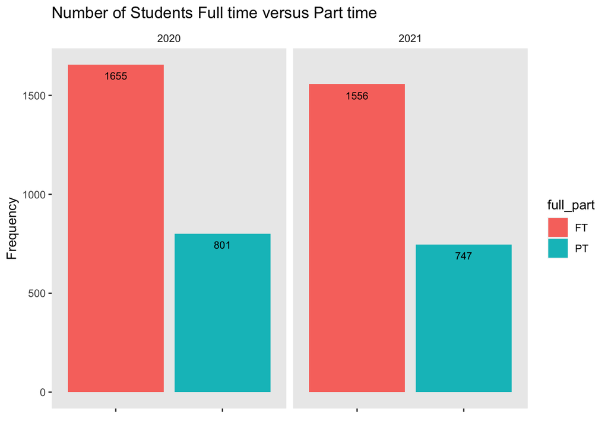

```r
# Number of students part time abnd full time  2020 vs 2021
ggplot(data=df_MCPS20D, aes(x=full_part, fill=full_part)) +
      geom_bar() +
      geom_text(stat='count', aes(label=..count..), vjust=2,size=3)+
      facet_wrap(~term_year)+
      ggtitle("Number of Students Full time versus Part time")+
      ylab('Frequency')+
      xlab("")+
      theme(axis.text.x=element_blank(),strip.background = element_blank(),panel.grid = element_blank())
```

```r
# change in overall MCPS student population from 2020 to 2021

df_MCPS20D%>%
          group_by(term_year,full_part)%>%
          count(full_part)%>%
          group_by(term_year)%>%
          mutate(total_pop =sum(n))%>%
          group_by(full_part)%>%
          arrange(term_year,.by_group=TRUE)%>%
          mutate(pct_change= (n-lag(n))/lag(n)*100)
```

```
## # A tibble: 4 x 5
## # Groups:   full_part [2]
##   term_year full_part     n total_pop pct_change
##       <dbl> <chr>     <int>     <int>      <dbl>
## 1      2020 FT         1655      2456      NA
## 2      2021 FT         1556      2303      -5.98
## 3      2020 PT          801      2456      NA
## 4      2021 PT          747      2303      -6.74
```

There was a 5.98% decrease in full time students who graduated from MCPS highschools in term year 2021. There was a -6.74% decrease in part time students who graduated from MCPS.

## 4.2 Race

Count of Race Groups

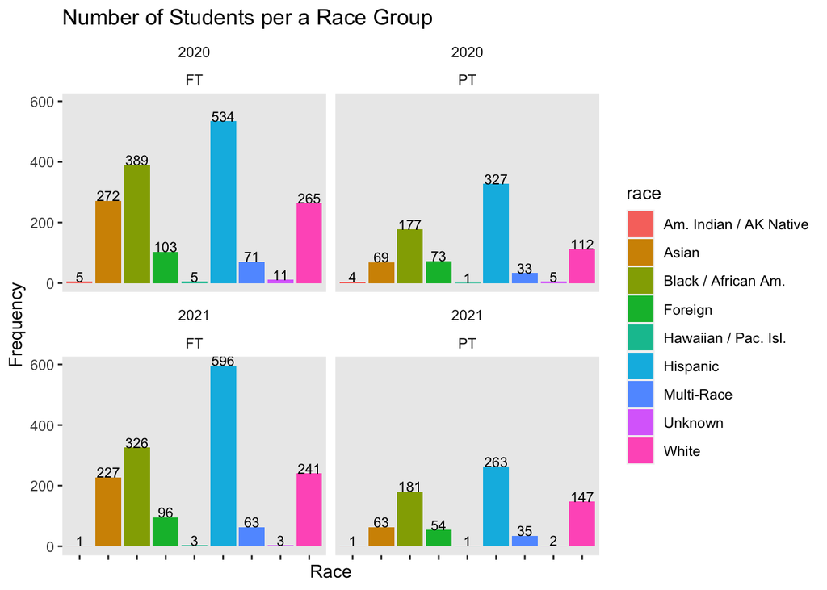

```r
ggplot(data=df_MCPS20D, aes(x=race, fill=race)) +
      geom_bar() +
      geom_text(stat='count', aes(label=..count..), vjust=0,size=3)+
      facet_wrap(~term_year + full_part)+
      theme(axis.text.x=element_blank(),strip.background = element_blank(),panel.grid = element_blank())+
      ggtitle("Number of Students per a Race Group")+
      xlab("Race")+
      ylab("Frequency")
```

Full time student: Change in enrollment from 2020 to 2021 based on Race

```r
# calculate percentage change in full time student enrollment from 2020 to 2021 by  race

df_MCPS20D%>%
          filter(full_part=="FT")%>%
          group_by(term_year,race)%>%
          count(race)%>%
          group_by(race)%>%
          arrange(term_year,.by_group=TRUE)%>%
          mutate(pct_change= (n-lag(n))/lag(n)*100)
```

```
## # A tibble: 18 x 4
## # Groups:   race [9]
##    term_year race                       n pct_change
##        <dbl> <chr>                  <int>      <dbl>
##  1      2020 Am. Indian / AK Native     5      NA
##  2      2021 Am. Indian / AK Native     1     -80
##  3      2020 Asian                    272      NA
##  4      2021 Asian                    227     -16.5
##  5      2020 Black / African Am.      389      NA
##  6      2021 Black / African Am.      326     -16.2
##  7      2020 Foreign                  103      NA
##  8      2021 Foreign                   96      -6.80
##  9      2020 Hawaiian / Pac. Isl.       5      NA
## 10      2021 Hawaiian / Pac. Isl.       3     -40
## 11      2020 Hispanic                 534      NA
## 12      2021 Hispanic                 596      11.6
## 13      2020 Multi-Race                71      NA
## 14      2021 Multi-Race                63     -11.3
## 15      2020 Unknown                   11      NA
## 16      2021 Unknown                    3     -72.7
## 17      2020 White                    265      NA
## 18      2021 White                    241      -9.06
```

Full time students: There was a 16.5% decline in asian students, 16.1% decline in African American students, a 9.1% decline in white students and 6.8% decline in foreign students. Hispanic students increased by 11.6%.

Part time student: Change in enrollment from 2020 to 2021 based on Race

```r
# calculate percentage change in full time student enrollment from 2020 to 2021 by  race

df_MCPS20D%>%
          filter(full_part=="PT")%>%
          group_by(term_year,race)%>%
          count(race)%>%
          group_by(race)%>%
          arrange(term_year,.by_group=TRUE)%>%
          mutate(pct_change= (n-lag(n))/lag(n)*100)
```

```
## # A tibble: 18 x 4
## # Groups:   race [9]
##    term_year race                       n pct_change
##        <dbl> <chr>                  <int>      <dbl>
##  1      2020 Am. Indian / AK Native     4      NA
##  2      2021 Am. Indian / AK Native     1     -75
##  3      2020 Asian                     69      NA
##  4      2021 Asian                     63      -8.70
##  5      2020 Black / African Am.      177      NA
##  6      2021 Black / African Am.      181       2.26
##  7      2020 Foreign                   73      NA
##  8      2021 Foreign                   54     -26.0
##  9      2020 Hawaiian / Pac. Isl.       1      NA
## 10      2021 Hawaiian / Pac. Isl.       1       0
## 11      2020 Hispanic                 327      NA
## 12      2021 Hispanic                 263     -19.6
## 13      2020 Multi-Race                33      NA
## 14      2021 Multi-Race                35       6.06
## 15      2020 Unknown                    5      NA
## 16      2021 Unknown                    2     -60
## 17      2020 White                    112      NA
## 18      2021 White                    147      31.2
```

Part time students: There was an 8.7% decrease in Asian students, a 26% decrease in foreign students, 2.3% increase in african american students and a 19.6% decrease in hispanic students. There was a 31.25% increase in white students.

## 4.3 Gender

Gender of Students

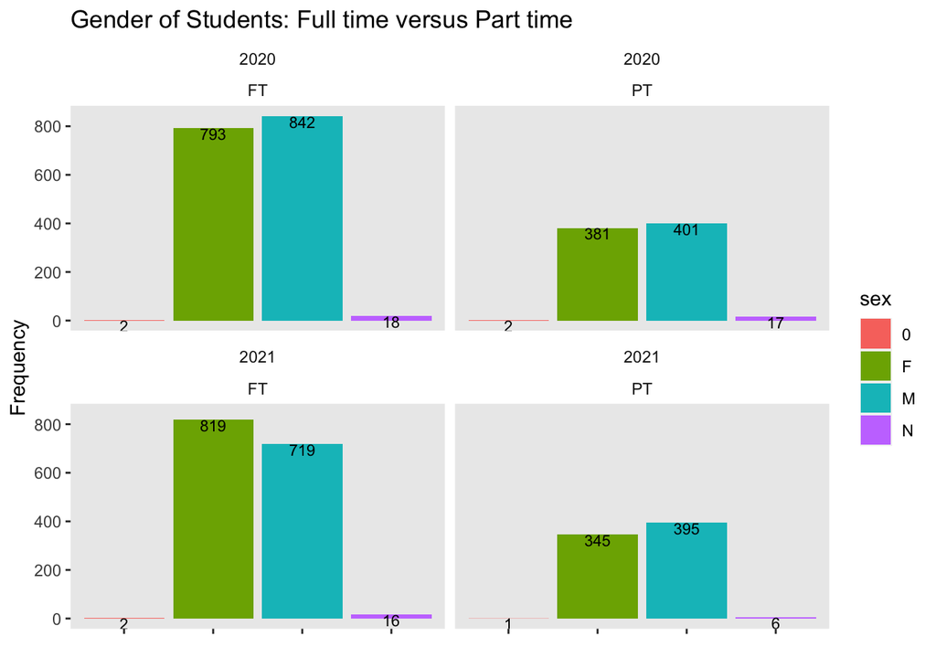

```r
# Gender of students part time and full time  2020 vs 2021
ggplot(data=df_MCPS20D, aes(x=sex, fill=sex)) +
      geom_bar() +
      geom_text(stat='count', aes(label=..count..), vjust=1,size=3)+
      facet_wrap(~term_year+full_part)+
      ggtitle("Gender of Students: Full time versus Part time")+
      ylab('Frequency')+
      xlab("")+
      theme(axis.text.x=element_blank(),strip.background = element_blank(),panel.grid = element_blank())
```

Calculate percentage change in full time student enrollment from 2020 to 2021 by gender

```r
# calculate percentage change in full time student enrollment from 2020 to 2021 by  gender

df_MCPS20D%>%
          filter(full_part=="FT")%>%
          filter(sex=="F"|sex =="M")%>%
          group_by(term_year,sex)%>%
          count(sex)%>%
          group_by(sex)%>%
          arrange(term_year,.by_group=TRUE)%>%
          mutate(pct_change= (n-lag(n))/lag(n)*100)
```

```
## # A tibble: 4 x 4
## # Groups:   sex [2]
##   term_year sex       n pct_change
##       <dbl> <chr> <int>      <dbl>
## 1      2020 F       793      NA
## 2      2021 F       819       3.28
## 3      2020 M       842      NA
## 4      2021 M       719     -14.6
```

Calculate percentage change in part time student enrollment from 2020 to 2021 by gender

```r
# calculate percentage change in part time student enrollment from 2020 to 2021 by  gender

df_MCPS20D%>%
          filter(full_part=="PT")%>%
          filter(sex=="F"|sex =="M")%>%
          group_by(term_year,sex)%>%
          count(sex)%>%
          group_by(sex)%>%
          arrange(term_year,.by_group=TRUE)%>%
          mutate(pct_change= (n-lag(n))/lag(n)*100)
```

```
## # A tibble: 4 x 4
## # Groups:   sex [2]
##   term_year sex       n pct_change
##       <dbl> <chr> <int>      <dbl>
## 1      2020 F       381      NA
## 2      2021 F       345      -9.45
## 3      2020 M       401      NA
## 4      2021 M       395      -1.50
```

Part time: 9.5% decrease in female students. 1.5% decrease in male students.

Gender and Race breakdown of full time students

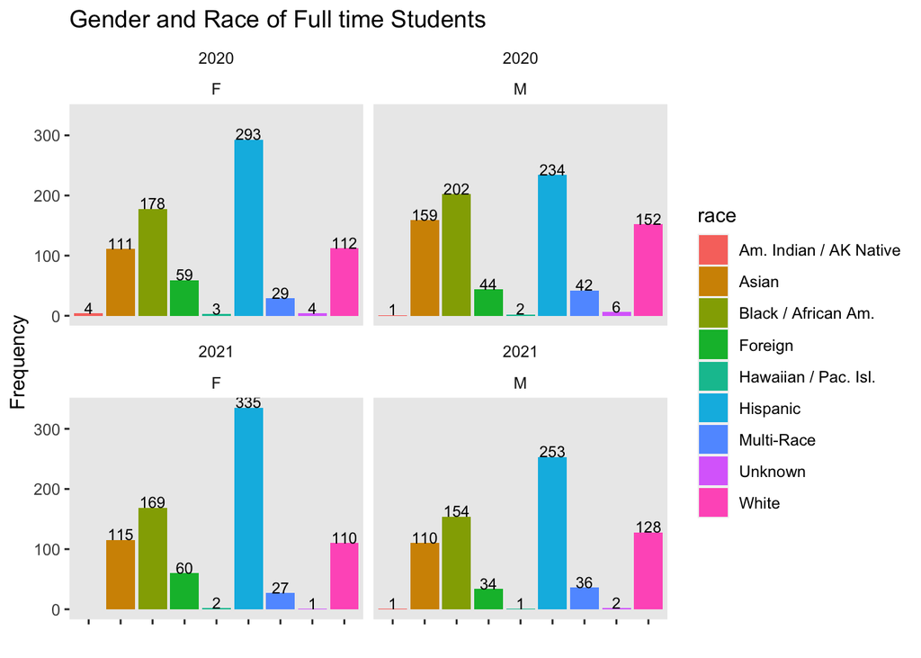

```r
# Gender and Race of full time students  2020 vs 2021

df_MCPS20D%>%
      filter(sex %in% c("F","M"))%>%
      filter(full_part=="FT")%>%
      ggplot(., aes(x=race, fill=race)) +
      geom_bar() +
      geom_text(stat='count', aes(label=..count..), vjust=0, size=3)+
      facet_wrap(~term_year+sex)+
      ggtitle("Gender and Race of Full time Students")+
      ylab('Frequency')+
      xlab("")+
      theme(axis.text.x=element_blank(),strip.background = element_blank(),panel.grid = element_blank())
```

```r
#    theme(axis.text.x=element_blank(),strip.background = element_blank(),panel.grid = element_blank())
```

Full time Student Enrollment Percentages trend by Gender and race

```r
# calculate percentage change in student enrollment from 2020 to 2021 by race and gender

# create data frames with counts of full time students by race and gender
df_MCPS20D%>%
          filter(full_part=="FT")%>%
          filter(sex=="F"|sex =="M")%>%
          group_by(term_year,race,sex)%>%
          count(sex)%>%
          group_by(race,sex)%>%
          arrange(term_year,.by_group=TRUE)%>%
          mutate(pct_change= (n-lag(n))/lag(n)*100)
```

```
## # A tibble: 35 x 5
## # Groups:   race, sex [18]
##    term_year race                   sex       n pct_change
##        <dbl> <chr>                  <chr> <int>      <dbl>
##  1      2020 Am. Indian / AK Native F         4      NA
##  2      2020 Am. Indian / AK Native M         1      NA
##  3      2021 Am. Indian / AK Native M         1       0
##  4      2020 Asian                  F       111      NA
##  5      2021 Asian                  F       115       3.60
##  6      2020 Asian                  M       159      NA
##  7      2021 Asian                  M       110     -30.8
##  8      2020 Black / African Am.    F       178      NA
##  9      2021 Black / African Am.    F       169      -5.06
## 10      2020 Black / African Am.    M       202      NA
## # … with 25 more rows
```

Part time Student Enrollment Percentages trend by Gender and race

```r
# calculate percentage change in student enrollment from 2020 to 2021 by race and gender

# create data frames with counts of full time students by race and gender
df_MCPS20D%>%
          filter(full_part=="PT")%>%
          filter(sex=="F"|sex =="M")%>%
          group_by(term_year,race,sex)%>%
          count(sex)%>%
          group_by(race,sex)%>%
          arrange(term_year,.by_group=TRUE)%>%
          mutate(pct_change= (n-lag(n))/lag(n)*100)
```

```
## # A tibble: 31 x 5
## # Groups:   race, sex [17]
##    term_year race                   sex       n pct_change
##        <dbl> <chr>                  <chr> <int>      <dbl>
##  1      2020 Am. Indian / AK Native M         4      NA
##  2      2021 Am. Indian / AK Native M         1     -75
##  3      2020 Asian                  F        30      NA
##  4      2021 Asian                  F        19     -36.7
##  5      2020 Asian                  M        37      NA
##  6      2021 Asian                  M        44      18.9
##  7      2020 Black / African Am.    F        79      NA
##  8      2021 Black / African Am.    F        84       6.33
##  9      2020 Black / African Am.    M        96      NA
## 10      2021 Black / African Am.    M        94      -2.08
## # … with 21 more rows
```

### 4.3.1 Majors

Overall Majors trend

Count of Majors in Full time students in 2020

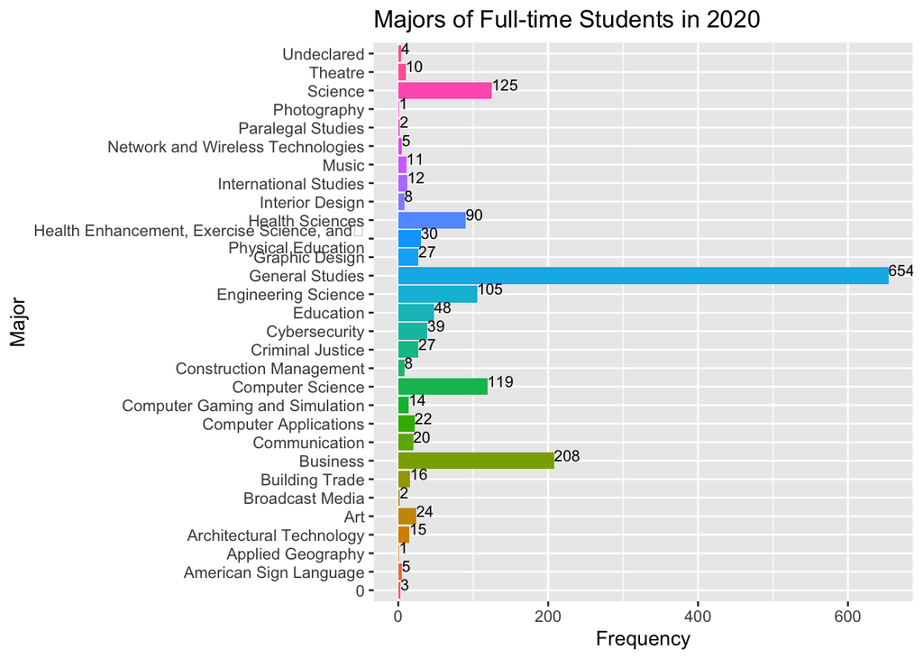

```r
z1<- df_MCPS20D%>%
      filter(full_part=="FT" &term_year =="2020")%>%
       ggplot(., aes(x=major, fill=major)) +
      geom_bar() +
      geom_text(stat='count', aes(label=..count..), vjust=0, hjust=0, size =3)+
      ggtitle("Majors of Full-time Students in 2020  ")+
      xlab("Major")+
      ylab("Frequency")+
    theme(legend.position = "none")

z1 + coord_flip()
```

Count of Majors in Full time students in 2021

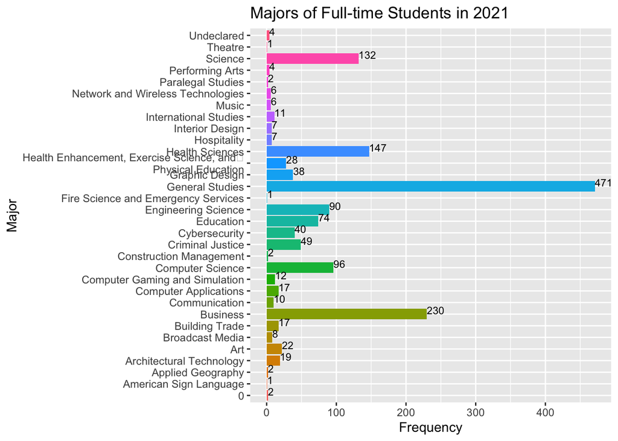

```r
z13<- df_MCPS20D%>%
      filter(full_part=="FT" &term_year =="2021")%>%
       ggplot(., aes(x=major, fill=major)) +
      geom_bar() +
      geom_text(stat='count', aes(label=..count..), vjust=0, hjust=0, size =3)+
      ggtitle("Majors of Full-time Students in 2021  ")+
      xlab("Major")+
      ylab("Frequency")+
    theme(legend.position = "none")

z13 + coord_flip()
```

calculate percentage change in full time student majors from 2020 to 2021

```r
df_MCPS20D%>%
          filter(full_part=="FT")%>%
          group_by(term_year,major)%>%
          count(major)%>%
          group_by(term_year)%>%
          group_by(major)%>%
          arrange(term_year,.by_group=TRUE)%>%
          mutate(pct_change= (n-lag(n))/lag(n)*100)
```

```
## # A tibble: 62 x 4
## # Groups:   major [33]
##    term_year major                        n pct_change
##        <dbl> <chr>                    <int>      <dbl>
##  1      2020 0                            3      NA
##  2      2021 0                            2     -33.3
##  3      2020 American Sign Language       5      NA
##  4      2021 American Sign Language       1     -80
##  5      2020 Applied Geography            1      NA
##  6      2021 Applied Geography            2     100
##  7      2020 Architectural Technology    15      NA
##  8      2021 Architectural Technology    19      26.7
##  9      2020 Art                         24      NA
## 10      2021 Art                         22      -8.33
## # … with 52 more rows
```

Count of Majors in Part time students in 2020

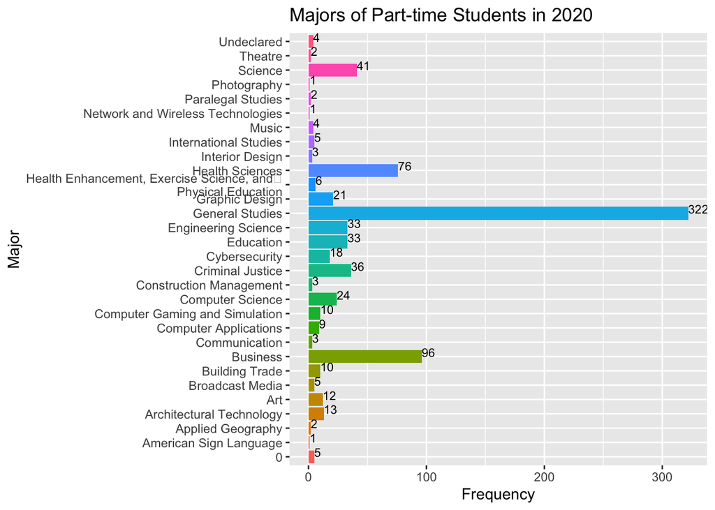

```r
z11<- df_MCPS20D%>%
      filter(full_part=="PT" &term_year =="2020")%>%
       ggplot(., aes(x=major, fill=major)) +
      geom_bar() +
      geom_text(stat='count', aes(label=..count..), vjust=0, hjust=0, size =3)+
      ggtitle("Majors of Part-time Students in 2020  ")+
      xlab("Major")+
      ylab("Frequency")+
    theme(legend.position = "none")

z11 + coord_flip()
```

Count of Majors in Part time students in 2021

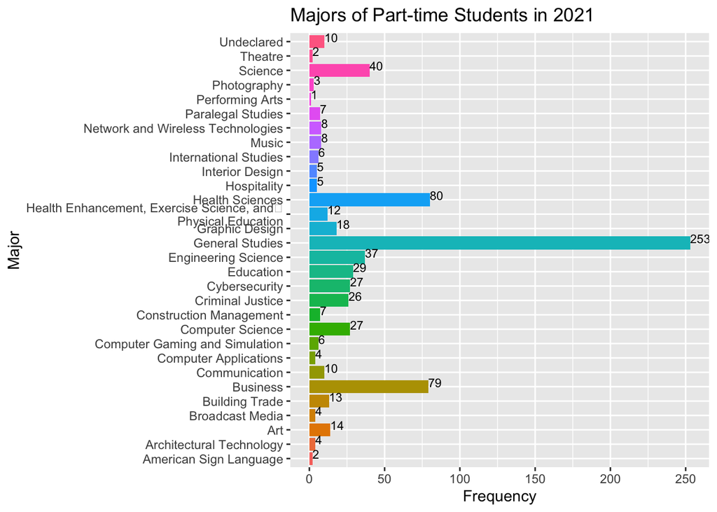

```r
z12<- df_MCPS20D%>%
      filter(full_part=="PT" &term_year =="2021")%>%
       ggplot(., aes(x=major, fill=major)) +
      geom_bar() +
      geom_text(stat='count', aes(label=..count..), vjust=0, hjust=0, size =3)+
      ggtitle("Majors of Part-time Students in 2021  ")+
      xlab("Major")+
      ylab("Frequency")+
    theme(legend.position = "none")

z12 + coord_flip()
```

calculate percentage change in part time student majors from 2020 to 2021

```r
df_MCPS20D%>%
          filter(full_part=="PT")%>%
          group_by(term_year,major)%>%
          count(major)%>%
          group_by(term_year)%>%
          group_by(major)%>%
          arrange(term_year,.by_group=TRUE)%>%
          mutate(pct_change= (n-lag(n))/lag(n)*100)
```

```
## # A tibble: 60 x 4
## # Groups:   major [32]
##    term_year major                        n pct_change
##        <dbl> <chr>                    <int>      <dbl>
##  1      2020 0                            5       NA
##  2      2020 American Sign Language       1       NA
##  3      2021 American Sign Language       2      100
##  4      2020 Applied Geography            2       NA
##  5      2020 Architectural Technology    13       NA
##  6      2021 Architectural Technology     4      -69.2
##  7      2020 Art                         12       NA
##  8      2021 Art                         14       16.7
##  9      2020 Broadcast Media              5       NA
## 10      2021 Broadcast Media              4      -20
## # … with 50 more rows
```

# 5 Statistical Analysis

For the purposes of this analysis I will run the analysis first with outliers and then after removing outliers. Special permission is required by students to attempt more than 18hours in a semester. Hence students who enroll in more than 18hours can be considered outliers.

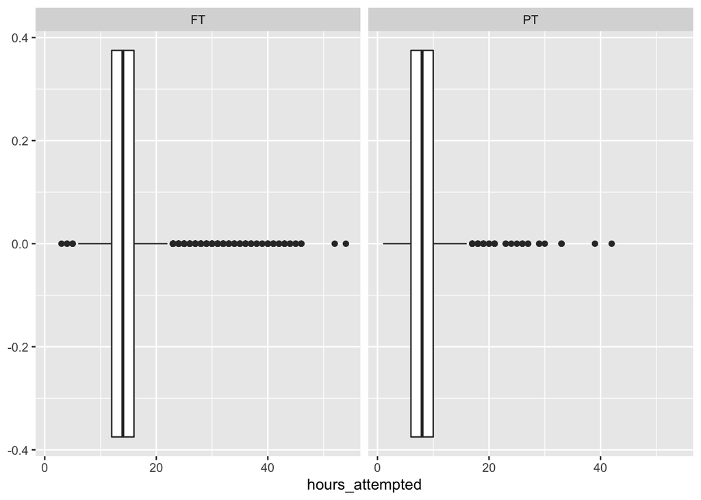

```r
p11 = ggplot(df_MCPS20D, aes(hours_attempted))
p11 + geom_boxplot(aes(colour = term_year)) +
       facet_wrap(~full_part)
```

Students who register for more than 18 credits require special permission from the department. Further more a full time student is classified as someone who is enrolled in 12 or more credits. A part time student is classified as someone who is enrolled in less than 12 credits

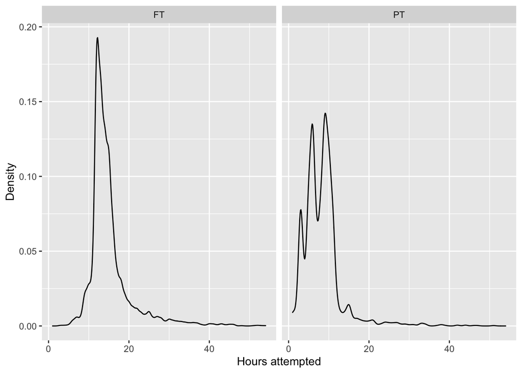

```r
ggplot(degrees_df, aes(hours_attempted, fill = term_year)) + geom_density(alpha = 0.2) +
  facet_wrap(~full_part)+
  xlab("Hours attempted") +
  ylab( "Density")
```